# sample size in two sample test

Main content: For hypothesis test of mean parameters of two normal distribution $H_0:\mu_1=\mu_2$ vs $H_1:\mu_1 \neq \mu_2$ with known $\sigma_1^2,\sigma_2^2$, how to calculate the minimum sample size when controlling type I error under $\alpha$ and type II error under $\beta$.

# model assumption, hypothesis test and power function

## model assumption

Suppose two independent i.i.d sample $x_1,\ldots,x_m \sim N(\mu_1,\sigma_1^2) \quad y_1,\ldots,y_n \sim N(\mu_2,\sigma_2^2)$

Under this model assumption, it is always true that:

$$\bar{x}-\bar{y} \sim
N(\mu_1-\mu_2,\frac{\sigma_1^2}{m}+\frac{\sigma_2^2}{n})$$

i.e.
$$u^* =
\frac{\bar{x}-\bar{y}-(\mu_1-\mu_2)}{\sqrt{\frac{\sigma_1^2}{m}+\frac{\sigma_2^2}{n}}}
\sim N(0,1)$$

## hypothesis test and power function

Suppose $\sigma_1^2$ and $\sigma_2^2$ are known, and we want to test the unknown mean parameters as:

$$H_0:\mu_1=\mu_2\quad \text{vs} \quad
H_1:\mu_1 \neq \mu_2$$

For this test, we set the test statistic to be $u = \frac{\bar{x}-\bar{y}}{\sqrt{\frac{\sigma_1^2}{m}+\frac{\sigma_2^2}{n}}}$ and rejection region’s form as $W=\{|u| \geq c\}$.

Then we can calculate the power function as the probability of sample in rejection region

$$\begin{align}
g(\mu_1,\mu_2,m,n,c) &= P(|u| \geq c)\\
& =
P(\left|\frac{\bar{x}-\bar{y}}{\sqrt{\frac{\sigma_1^2}{m}+\frac{\sigma_2^2}{n}}}\right|\geq
c)\\
&=P(
\left|\frac{\bar{x}-\bar{y}-(\mu_1-\mu_2)}{\sqrt{\frac{\sigma_1^2}{m}+\frac{\sigma_2^2}{n}}}
+
\frac{(\mu_1-\mu_2)}{\sqrt{\frac{\sigma_1^2}{m}+\frac{\sigma_2^2}{n}}}\right|
\geq c)\\
&=P( \left|u^* +
\frac{(\mu_1-\mu_2)}{\sqrt{\frac{\sigma_1^2}{m}+\frac{\sigma_2^2}{n}}}\right|
\geq c)\\
& = P( u^* +
\frac{(\mu_1-\mu_2)}{\sqrt{\frac{\sigma_1^2}{m}+\frac{\sigma_2^2}{n}}}
\geq |c|) + P( u^* +
\frac{(\mu_1-\mu_2)}{\sqrt{\frac{\sigma_1^2}{m}+\frac{\sigma_2^2}{n}}}
\leq -|c|)\\
& = P(u^* \geq
|c|-\frac{(\mu_1-\mu_2)}{\sqrt{\frac{\sigma_1^2}{m}+\frac{\sigma_2^2}{n}}})
+ P(u^* \leq -|c| -
\frac{(\mu_1-\mu_2)}{\sqrt{\frac{\sigma_1^2}{m}+\frac{\sigma_2^2}{n}}})\\
& =
1-\Phi(|c|-\frac{(\mu_1-\mu_2)}{\sqrt{\frac{\sigma_1^2}{m}+\frac{\sigma_2^2}{n}}})
+ \Phi(-|c| -
\frac{(\mu_1-\mu_2)}{\sqrt{\frac{\sigma_1^2}{m}+\frac{\sigma_2^2}{n}}})
\end{align}$$

# control type I error to define the reject region and set the test

Let’s consider controlling type I error under $\alpha$ to set the reject region(thus the test).

Type I error rate function is the power function when $H_0: \mu_1=\mu_2$ holds:

$$\begin{align}
\alpha(c)
&= g(\mu_1,\mu_2,m,n,c),\quad \mu_1=\mu_2 \\
&=
1-\Phi(|c|-\frac{(\mu_1-\mu_2)}{\sqrt{\frac{\sigma_1^2}{m}+\frac{\sigma_2^2}{n}}})
+ \Phi(-|c| -
\frac{(\mu_1-\mu_2)}{\sqrt{\frac{\sigma_1^2}{m}+\frac{\sigma_2^2}{n}}}),
\quad \mu_1=\mu_2\\
& = 1-\Phi(|c|)+\Phi(-|c|)\\
& = 2(1-\Phi(|c|))
\end{align}$$

Let $\alpha(c) = \alpha$, we get $c=u_{\alpha/2}$, so the rejection region is $W=\{|u| \geq u_{\alpha/2}\}$, and the test is

$$T:
\begin{cases}
\frac{\bar{x}-\bar{y}}{\sqrt{\sigma_1^2/m+\sigma_2^2/n}}\leq
u_{\alpha/2}, & \text{reject}~H_0\\
\frac{\bar{x}-\bar{y}}{\sqrt{\sigma_1^2/m+\sigma_2^2/n}} >
u_{\alpha/2}, & \text{accept}~H_0
\end{cases}$$

# having the test defined, control type II error to get the minimum sample size

Having set the test, we then consider controlling type II error under $\beta$ to get the minimum sample size(later we suppose $n=m$)

Type II error rate function is equal to $1$ minus the power function when $H_1$ holds as $\mu_1-\mu_2 = \delta \neq 0$:

$$\begin{align}
\beta(\delta,m,n)
& = 1- g(\mu_1,\mu_2,m,n,u_{\alpha/2}), \quad \mu_1-\mu_2 = \delta\\
& = \Phi(\left|u_{\alpha/2}\right| -
\frac{\delta}{\sqrt{\frac{\sigma_1^2}{m}+\frac{\sigma_2^2}{n}}}-\Phi(-\left|u_{\alpha/2}\right|
- \frac{\delta}{\sqrt{\frac{\sigma_1^2}{m}+\frac{\sigma_2^2}{n}}})\\
\end{align}$$

Let $m=n$ so

$$\beta(\delta,n)
= \Phi(\left|u_{\alpha/2}\right| -
\frac{\delta}{\sqrt{(\sigma_1^2+\sigma_2^2)/n}}-\Phi(-\left|u_{\alpha/2}\right|
- \frac{\delta}{\sqrt{(\sigma_1^2+\sigma_2^2)/n}})$$

Note that $\beta(\delta,n)$ is symmetric(see figure 1) with respect to $\delta$, such that $\beta(\delta)=\beta(-\delta) =\beta(|\delta|)$, so the type II rate function equals:

$$\begin{align}
\beta(\delta,n)
& = \Phi(\left|u_{\alpha/2}\right| -
\frac{\delta}{\sqrt{(\sigma_1^2+\sigma_2^2)/n}})-\Phi(-\left|u_{\alpha/2}\right|
- \frac{\delta}{\sqrt{(\sigma_1^2+\sigma_2^2)/n}})\\
& = \Phi(\left|u_{\alpha/2}\right| -
\frac{|\delta|}{\sqrt{(\sigma_1^2+\sigma_2^2)/n}})-\Phi(-\left|u_{\alpha/2}\right|
- \frac{|\delta|}{\sqrt{(\sigma_1^2+\sigma_2^2)/n}})\\
& = \Phi(-u_{\alpha/2} -
\frac{|\delta|}{\sqrt{(\sigma_1^2+\sigma_2^2)/n}})-\Phi(u_{\alpha/2} -
\frac{|\delta|}{\sqrt{(\sigma_1^2+\sigma_2^2)/n}}),
\quad(u_{\alpha/2}<0)\\
\end{align}$$

Note that $\Phi(u_{\alpha/2} - \frac{|\delta|}{\sqrt{(\sigma_1^2+\sigma_2^2)/n}})\leq \alpha/2 \approx 0$, so we omit this term for convenience. Thus, the type II error rate function is approximately:

$$\begin{align}
\beta(\delta,n)
& = \Phi(-u_{\alpha/2} -
\frac{|\delta|}{\sqrt{(\sigma_1^2+\sigma_2^2)/n}})-\Phi(u_{\alpha/2} -
\frac{|\delta|}{\sqrt{(\sigma_1^2+\sigma_2^2)/n}})\\
& \approx \Phi(-u_{\alpha/2} -
\frac{|\delta|}{\sqrt{(\sigma_1^2+\sigma_2^2)/n}})\\
\end{align}$$

For a given ground truth under $H_1$ where $\mu_1-\mu_2=\delta \neq 0$, $\Phi(-u_{\alpha/2} - \frac{|\delta|}{\sqrt{(\sigma_1^2+\sigma_2^2)/n}})$ is a decreasing function of $n$(see figure 2). Let $\Phi(-u_{\alpha/2} - \frac{|\delta|}{\sqrt{(\sigma_1^2+\sigma_2^2)/n}}) \leq \beta$, then the sample size region is given by
$$n
\geq
\frac{(u_{\alpha/2}+u_{\beta})^2(\sigma_1^2+\sigma_2^2)}{|\delta|^2}$$

# appendix

$\beta(\delta,n=30)$, set $\sigma_1^2=1,\sigma_2^2 =1, \alpha = 0.05$

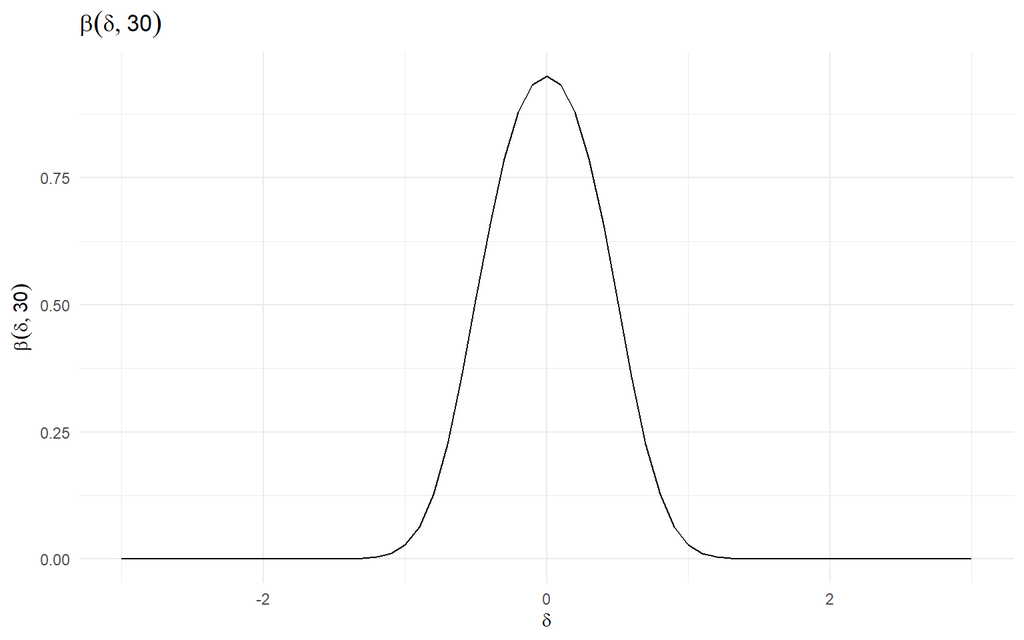

$\beta(\delta=1,n)$, set $\sigma_1^2=1,\sigma_2^2 =1, \alpha = 0.05$

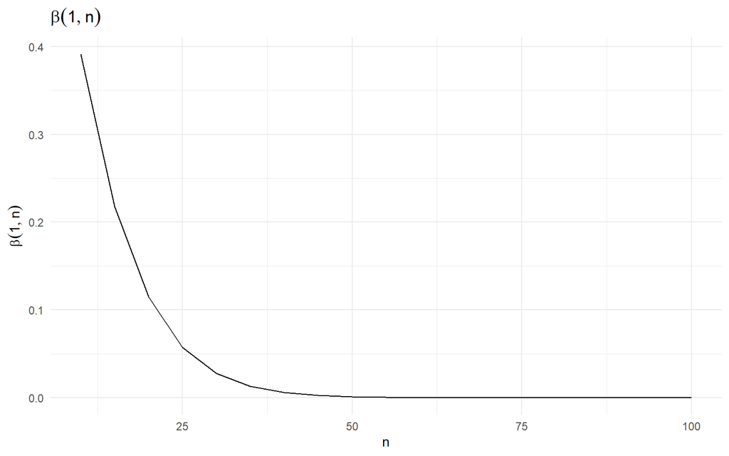